# Final Project Report

Data Dawgs and Dawgette

Author

Neal Agarwal, Emily Chan, Pranav Doradla, Srikrishna Sorna

Published

March 12, 2023

Abstract

## 1 Background / Motivation

What motivated you to work on this problem?

Mention any background about the problem, if it is required to understand your analysis later on.

In the 2021/2022 season the teams in the NBA generated a combined 10 billion dollars in revenue. This high revenue not only benefits team owners and players, but also the state and local economies in which these games are being played. Ultimately, the only way for there to be a high revenue for a team and an increase in spending for the local economy is if the team management chooses the best performing players for their team. The new basketball players selected every year are part of an official draft. This draft consists of 60 players and around 90% of these players are from college, and the other 10% may be from international programs or from the G League (the minor league organization of the NBA).

As loyal NBA fans and basketball enthusiasts, we have been quite disappointed with some of the NBA draft selections by our favorite organizations.There have been a plethora of cases each year where team management have seemed to pick a potential superstar only for them to turn out to be a failure in the NBA. We chose to investigate this issue and try to find any mathematical associations that may exist between college performance and point production in the NBA. We want to make sure that team owners can pick the best college players and continue to increase their economic impact in local communities.

## 2 Problem statement

Describe your problem statement. Articulate your objectives using absolutely no jargon. Interpret the problem as inference and/or prediction.

Examine how multiple basketball related variables are related to points per game in the NBA. This utilizes college basketball data for NCAA players who made it to the NBA in the year 2021 and test it on the scoring of NCAA players who made it to the NBA in the year 2022. We are looking to predict the points per game for each individual player and minimize the difference between our predicted values and the actual points scored. It is important to pay attention to the larger errors because we want to minimize the implied financial and basketball game losses of the team.

## 3 Data sources

What data did you use? Provide details about your data. Include links to data if you are using open-access data.

To address this problem, we scraped a website,(https://basketball.realgm.com/), with comprehensive data from individual players’ professional and collegiate careers. The scraped data was compiled into an excel file and then it was converted into a CSV so that it could easily be read using python libraries(pandas). The preliminary excel file had 4 different tables- NCAA 2021, NBA 2021, NCAA 2022, and NBA 2022. However, we added the NBA PPG column from the NBA tables to the NCAA Tables. This allowed us to remove the NBA 2021 and NBA 2022 tables and rename the NCAA 2021 as ncaa_train and NCAA 2022 as ncaa_test. The final datasets contained 23 columns: player names and 22 other numerical variables.

## 4 Stakeholders

Who cares? If you are successful, what difference will it make to them?

In the NBA, selecting rookies with the highest scoring potential is important to the team’s performance and their organization’s value. The people most interested in our analysis would be the Team Owner, Head Coach and General Manager (GM). The owner of an NBA team is trying to make sure that they are making a return on their investment. They are only able to increase their team’s valuation if tickets, merchandise, concessions, and more are consistently being sold. These things will only occur if the team wins championships and there is a loyal fanbase. The GM and head coach oversee constructing a team that will have the potential to win championships. The team will win when they have the highest point scorers and best defenders. Our analysis is one of the tools they can use to enhance and quicken the evaluation process of their new draft class. It will help them shorten their analytical process as they can focus on specific variables that translate to better point production in the NBA and they can spend more of their time scouting the college player in person.

## 5 Data quality check / cleaning / preparation

In a tabular form, show the distribution of values of each variable used in the analysis - for both categorical and continuous variables. Distribution of a categorical variable must include the number of missing values, the number of unique values, the frequency of all its levels. If a categorical variable has too many levels, you may just include the counts of the top 3-5 levels.

Were there any potentially incorrect values of variables that required cleaning? If yes, how did you clean them?

Did you do any data wrangling or data preparation before the data was ready to use for model development? Did you create any new predictors from exisiting predictors? For example, if you have number of transactions and spend in a credit card dataset, you may create spend per transaction for predicting if a customer pays their credit card bill. Mention the steps at a broad level, you may put minor details in the appendix. Only mention the steps that ended up being useful towards developing your final model(s).

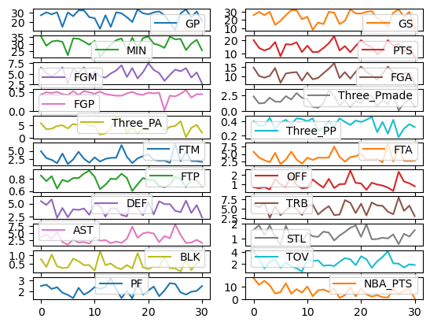

```python
import pandas as pd
import matplotlib.pyplot as plt
train = pd.read_csv('ncaa_train.csv')
train.plot(subplots=True, layout=(11,2))
plt.show()
```

No we did not have potentially incorrect values of the variables since we scraped the data ourselves from online. We worked with a dataset that is very complete and official by a big sports organization. This allowed us to find a great dataset that did not require much cleaning. Yes, we were able to wrangle the data ourselves because we had a lot of data to compile and organize to begin with. Since our dataset had began with every single player in the National Basketball Association, there was too much variation from player to player. So our first step in data preparation was to analyse only the players that were in the Guard positon. This allowed us to analyse a specific subset of data since too much variation can mean a bad model to begin with. Our second step was to also make sure each player had sufficient data to start since we want accurate results with similar data structures. We then made sure the data had a coherent transition from training to testing data in order to make sure we are not introducing any bias to the results. We also had to use a limited timeline of data since the game of NBA has changed over time so it would not be useful to use data from the beginning of basketball. This was a well versed dataset that was very useful and helped us a lot in making predictions.

## 6 Exploratory data analysis

Put the relevant EDA here (visualizations, tables, etc.) that helped you figure out useful predictors for developing the model(s). Only put the EDA that ended up being useful towards developing your final model(s).

List the insights (as bullet points) you got from EDA that ended up being useful towards developing your final model.

Again, if there are too many plots / tables, you may put them into appendix, and just mention the insights you got from them.

```python
train.corr()['NBA_PTS'].sort_values(ascending=False)
```

```
NBA_PTS        1.000000
GS             0.433931
FTP            0.351406
GP             0.337517
MIN            0.323561
STL            0.318212
FGM            0.270299
Three_Pmade    0.260686
PTS            0.249359
Three_PA       0.245180
DEF            0.228423
FGP            0.200565
FGA            0.191621
Three_PP       0.118538
BLK            0.104205
TRB            0.101691
PF             0.090852
TOV            0.073663
FTM            0.053743
AST           -0.007441
FTA           -0.015898
OFF           -0.241982
Name: NBA_PTS, dtype: float64
```

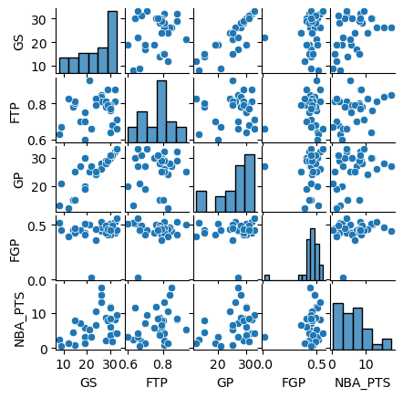

```python
import seaborn as sns
top4 = train[['GS','FTP','GP','FGP','NBA_PTS']]
g=sns.pairplot(top4)
g.fig.set_size_inches(4,4)
```

```python
from statsmodels.stats.outliers_influence import variance_inflation_factor
from statsmodels.tools.tools import add_constant
X = train[['GS', 'MIN', 'FGP','Three_PA', 'Three_PP', 'FTA', 'FTP', 'OFF', 'DEF', 'AST','STL', 'BLK', 'TOV', 'PF']]
X = add_constant(X)
vif_data = pd.DataFrame()
vif_data["feature"] = X.columns
for i in range(len(X.columns)):
    vif_data.loc[i,'VIF'] = variance_inflation_factor(X.values, i)
print(vif_data)
```

```
     feature         VIF
0      const  294.702398
1         GS    1.850221
2        MIN    3.732064
3        FGP    1.509959
4   Three_PA    3.387936
5   Three_PP    2.724658
6        FTA    3.472252
7        FTP    2.501875
8        OFF    2.318019
9        DEF    1.977811
10       AST    3.230762
11       STL    2.317251
12       BLK    2.074200
13       TOV    3.929724
14        PF    1.658651
```

## 7 Approach

What kind of a model (linear / logistic / other) did you use? What performance metric(s) did you optimize and why?

Is there anything unorthodox / new in your approach?

What problems did you anticipate? What problems did you encounter? Did the very first model you tried work?

Did your problem already have solution(s) (posted on Kaggle or elsewhere). If yes, then how did you build upon those solutions, what did you do differently? Is your model better as compared to those solutions in terms of prediction / inference?

## 8 Developing the model

Explain the steps taken to develop and improve the base model - informative visualizations / addressing modeling assumption violations / variable transformation / interactions / outlier treatment / influential points treatment / addressing over-fitting / addressing multicollinearity / variable selection - stepwise regression, lasso, ridge regression).

Did you succeed in achieving your goal, or did you fail? Why?

**Put the final model equation**.

**Important: This section should be rigorous and thorough. Present detailed information about decision you made, why you made them, and any evidence/experimentation to back them up.**

We also ran an outlier test on this model and found that none of the observations had a studentized residual that exceeded a magnitude of 3. Therefore, there were no outlying observations that needed to be handled. From the increase in RMSE and the still relatively moderate R-squared value, we concluded that we needed to use other methods to further improve our model fit, optimize RMSE, and determine the best subset of predictors.

From the subset of 6 predictors found by the stepwise regression, three variables (GS, OFF, TOV) were statistically significant. We used these three variables to do a 5-fold cross validation, from which we reached a new optimal RMSE value of 5.848066627524104. The interaction term found by the k-fold cross validation was GS*TOV.

After using a 5-fold cross validation, we decided to implement a ridge regression model in our analysis. We standardized predictors so that each of them have zero mean and unit variance and found the ridge regression coefficients. After finding the coefficients, we visualized the shrinkage in regression coefficients and found the predictors that shrank the most to be MIN, PTS, Three_PP, and FGP. We then reduced the range of our alpha to visualize the minimum and found our optimal tuning parameter to be 15.81. Before using the ridge regression model to predict on test data, we standardized the test data. Then we obtained a prediction using the standardized data and calculated an RMSE of 5.13- the new optimal RMSE value.

We also then ran a Lasso regression by first visualizing the shrinkage in lasso coefficients with increasing values of the tuning parameter lambda. And before that we had to also standardize the test data. The optimal tuning parameter turned out to be 0.05 which meant the coefficients have shrunk to 0 and effectively eliminated 10 variables [Player, GS, MIN, FGM, FGP, Three_Pmade, Three_PP, DEF, STL, BLK]. We also made sure to visualize the LOOCV (leave one out cross validatation error vs lambda). The lasso regression method is usually used in machine learning for the selection of the best subset of variables. It provides greater prediction accuracy as compared to all of the other regression models. Lasso Regularization also helps to increase model interpretation. We have also noted that the R-squared on train data and test data for the Lasso Model were both negative values.This led us to deduce that the model was indeed overparameterized which is why we then continued to shrink the coefficients to improve. And finally we used the developed lasso model to predict on test data and got an RMSE value of 5.45 which ended up being pretty decent in comparison to what we usually got.

The final model equation is: NBA_PTS~GS+OFF+TOV+GS*TOV

The final model had an R-squared of 0.398, an RSE (training error) of 3.577 and an RMSE of 5.848. While the RMSE increased compared to the lasso model, the R-squared was positive, which is why we chose this as our final model. More judgments on the final model follow in the Conclusions and Recommendations to Stakeholder(s) section.

## 9 Limitations of the model with regard to inference / prediction

If it is inference, will the inference hold for a certain period of time, for a certain subset of population, and / or for certain conditions.

If it is prediction, then will it be possible / convenient / expensive for the stakeholders to collect the data relating to the predictors in the model. Using your model, how soon will the stakeholder be able to predict the outcome before the outcome occurs. For example, if the model predicts the number of bikes people will rent in Evanston on a certain day, then how many days before that day will your model be able to make the prediction. This will depend on how soon the data that your model uses becomes available. If you are predicting election results, how many days / weeks / months / years before the election can you predict the results.

When will your model become too obsolete to be useful?

Gathering the data would be very inexpensive for the stakeholders. All of the data that was collected was open source and free. Hypothetically, our stakeholders would be able to make the predictions when the college players have played their last game. However, it would be more beneficial for them to integrate this data via an API so they can see how the players develop throughout the season so they do not have to wait until March to make a decision. Being able to integrate this model with live data at the beginning of a collegiate career would be helpful because one could see a continuous prediction over a long period of time and analyze the changes.

One of the limitations of our model is that we are limited to statistical learning techniques that are within the breadth of this class. With more data science knowledge this model could improve in many different ways. The model may become obsolete fast as newer machine learning techniques and more advanced models can prevent further overfitting and generalizations.

In terms of basketball, the model may become obsolete when the kind of basketball player changes. Basketball players have changed their methods of scoring throughout history and it will continue to evolve. For example, players 30 years ago used to attempt fewer three point shots and score closer to the basket. Now players are shooting more three pointers. When the majority of players change their playing style, the predictor variables may not carry the same weight as they have in our current model.

## 10 Conclusions and Recommendations to stakeholder(s)

What conclusions do you draw based on your model? If it is inference you may draw conclusions based on the coefficients, statistical significance of predictors / interactions, etc. If it is prediction, you may draw conclusions based on prediction accuracy, or other performance metrics.

How do you use those conclusions to come up with meaningful recommendations for stakeholders? The recommendations must be action-items for stakeholders that they can directly implement without any further analysis. Be as precise as possible. The stakeholder(s) are depending on you to come up with practically implementable recommendations, instead of having to think for themselves.

If your recommendations are not practically implementable by stakeholders, how will they help them? Is there some additional data / analysis / domain expertise you need to do to make the recommendations implementable?

Do the stakeholder(s) need to be aware about some limitations of your model? Is your model only good for one-time use, or is it possible to update your model at a certain frequency (based on recent data) to keep using it in the future? If it can be used in the future, then for how far into the future?

Our model is intended to be used as a way for those running NBA teams to select the best possible players (as measured by NBA_PTS) when drafting from the NCAA. As such it is useful for both inference and prediction. In terms of inference, our model revealed interesting insights on what makes a good NBA player, given his NCAA statistics. Our target variable was NBA_PTS, which refers to the number of points made by a given player when playing in the NBA; it is taken to be relatively indicative of how “good” a player is, as scoring points directly contributes to the success of a team in a game.

GS (games started) refers to the number of basketball games in which the coach put a given player into the court at the start of the game. It has a negative coefficient of -0.2502, which was surprising, as one would think that better players would be put on the starting lineup more often (NCAA coaches, in theory, know which players on their team are best), and better players are presumably the ones that go from the NCAA to the NBA, which would theoretically lead to a positive coefficient. One potential explanation is the following: if a player has started on too many games, they may get injured too often, and sustaining many small injuries in the long-term could reduce that player’s skill later on in the NBA.

TOV (turnovers) refers to the number of times that a given player allowed the opposing team to steal the ball from him. It has a relatively large negative coefficient of -4.4396, which is expected, as worse players are probably less athletic and more clumsy, attributes which would transfer over to them both having more turnovers and scoring less points in the NBA.

That said, not too much inference can be drawn from the coefficients on GS and TOV, as they are both insignificant on their own (p-values of 0.422 and 0.140, respectively). However, the interaction GS:TOV is significant within an alpha of 0.1 (p-value of 0.070) and has a positive coefficient of 0.2335. It is surprising that the interaction has a positive coefficient, because for the reasons noted in the previous paragraph, a greater TOV should be associated with a lower NBA_PTS. A possible interpretation of this is the players that often play in the starting lineup (higher GS) and allow for a high number of turnovers (higher TOV) do the latter because they simply have the ball in their hands more often, not because they are worse at keeping the ball away from the opposing team. This would then mean that those players are in fact even better, not worse, which fits with the observed fact that they then score more in the NBA (have higher NBA_PTS values).

OFF (offensive rebounds) refers to the number of times a given player rebounded the ball when playing offense, or grabbed the ball after his teammate missed a shot. It is significant within an alpha of 0.1 (p-value of 0.073) and has a coefficient of -2.3707. This was somewhat surprising at first because one would expect that increased offensive rebounds lead to more chances for the player’s team to shoot again, and that would help out the team as a whole. However, it is important to keep in mind that the target, NBA_PTS, only refers to the individual player’s points scored, not to his overall positive contribution to the team. Thus, one interpretation of this negative coefficient is that players that are not as good at scoring tend to be the ones rebounding (while the players that are good at scoring, that everyone passes the ball to because they entrust them with scoring, tend to shoot instead of rebounding).

The R-squared of 0.398 and RMSE of 5.848 show that perhaps there are other factors at play affecting a player’s scoring metrics that are unquantifiable, difficult to quantify, or simply not available in public datasets (which is quite likely, considering the myriad factors that go into creating a high-performing professional athlete). Cross-validation was used because the number of observations in train + test datasets, 61, was relatively small compared to our number of predictors. The RSE (training error) was 3.577, and the k-fold cross-validation score (using 60 folds, so essentially LOOCV) was 3.830. The fact that LOOCV error is only slightly higher than RSE shows that our model probably overfitted only slightly and not to a worrying degree. The model can be used to generate predictions for player scoring, but not with a very high degree of accuracy; it is far more useful for its inferential ability.

The only foreseeable limitation of our model is that in the future when the game of basketball changes over a long period of time, we may need to utilize more recent data. That does still mean our modelling procedures are still valid, we would just need newer data. If we can utilize this modelling with more recent data, we are confident that this model can be used as long as the regulations of National Basketball Association are the same. We rely on the fact that the NBA doesn’t change its rules of playing. So that is very far into the future of basketball and for many generations to come.

## GitHub and individual contribution

Put the **Github link** for the project repository.

https://github.com/krishnasorna/DataDawgsProject

Add details of each team member’s contribution in the table below.

## Individual contribution

| Team member | Contributed aspects | Details | Number of GitHub commits |
| --- | --- | --- | --- |
| Neal Agarwal | Data Cleaning, Data Wrangling, Ridge Regression | Cleaned data to compile useful dataset and developed variable transformations. Also performed Ridge Regression for additional modelling. | 8 |
| Emily Chan | EDA, Initial MLR, Forward Stepwise, K-Fold CV | Checked modeling assumptions and found relevant variable interactions via Forward Stepwise and K-Fold. | 15 |
| Pranav Doradla | Base Model, Outlier and influential points treatment, CV Scores | Identified outliers/influential points and found the CV score of the final model. | 11 |
| Srikrishna Sorna | Variable selection, Overfitting, Lasso Regression | Performed variable selection on predictors to address overfitting and also performed Lasso Regression to eliminate a subset of variables. | 13 |

List the **challenges** you faced when collaborating with the team on GitHub. Are you comfortable using GitHub? Do you feel GitHuB made collaboration easier? If not, then why? *(Individual team members can put their opinion separately, if different from the rest of the team)*

The challenges we first faced when using GitHub was learning how to commit and create pull requests. We were all new to GitHub so we are thankful to learn how to use this. We also faced problems in merge conflicts and had to create certain requests with each other to make sure we had the best code and updated files. We are comfortable using GitHub now as we had time to learn and we do think it has made collaboration easier. This is because we are able to communicate with code in an easy way and also easily make pull requests to our own laptops even if we are not in the same place together. This allowed us to work together from afar and made process easier to collaborate.